# Course Visualization Project

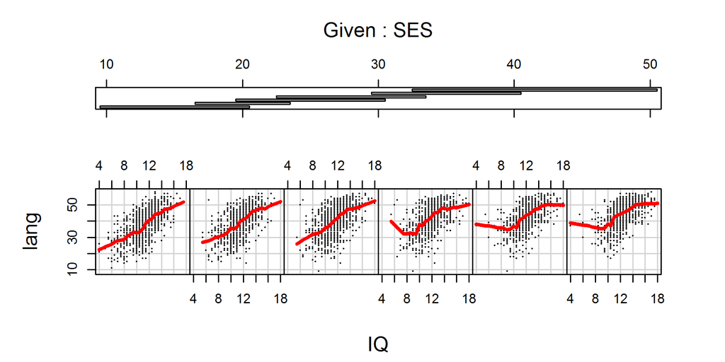

```r
#The same trend shows on the unscaled data. We are able to view the exact IQ, SES, and language test scores.
coplot(data= nlschools, lang ~ IQ  | SES, panel=panel.smooth, cex=.1, span=.1, rows=1, lwd=3)
```

Findings:

- The trends indicated that students with higher IQs tended to score high regardless of SES. Nevertheless, students with a lower IQ score may score higher or lower depending on thier socioeconomic status. It is clear that poorer students with a below average IQ in the first three graphs scored low, indicating an almost linear relationship that was unaffected by SES. However, the students with above average SES and had a lower than average IQ were able to attain higher scores than students with comparable IQs but lower SES. There is almost a u-shaped curve in the last three graphs.
- The u-shaped curve may indicate that the following scenario: low IQ students of above average SES status may recieve special attention and additional resources to aid them inpreparing for their language exam.
- Regardless, it is clear that there is an interaction between IQ and SES that contributes to predicting language scores.

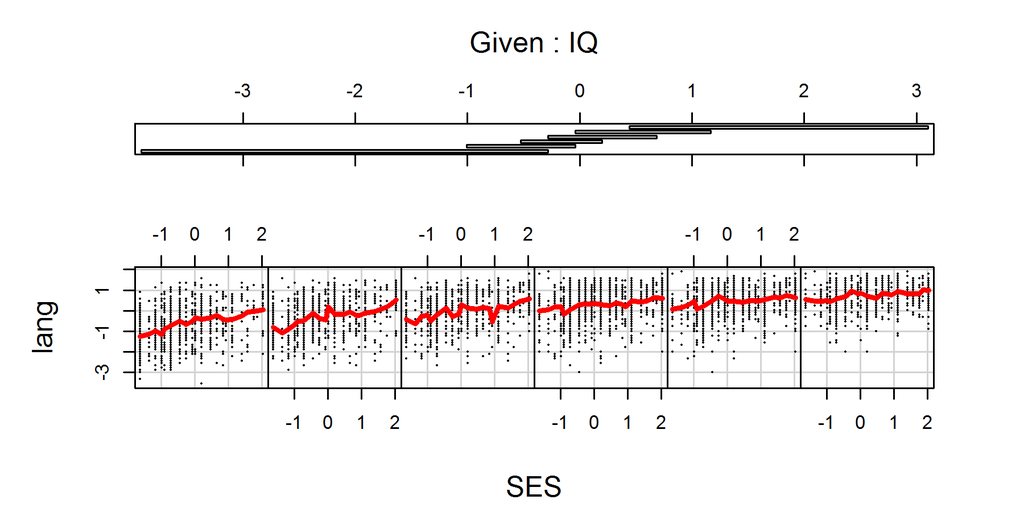

```r
#The last three graphs show a nearly hiorizontal trend, indicating that the above average IQ pupils ( above 0 [standardized]) tend to be among the higher SES score range.
coplot(data= scaled.nlschools, lang ~ SES  | IQ, panel=panel.smooth, cex=.1, span=.1, rows=1, lwd=3)
```

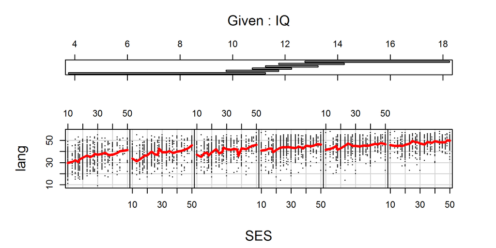

```r
#The trends are the same with the unscaled data.
#We can see that students with higher SES scores tended to score higher on the language exam. Nevertheless, given IQ, students withhigher IQs scored high regardless of their SES.
coplot(data= nlschools, lang ~ SES  | IQ, panel=panel.smooth, cex=.1, span=.1, rows=1, lwd=3)
```

Findings:

- Similar to the above.
- Also, it seem that the higher a pupil’s IQ the more likely the pupil may be of a higher SES.

MCluster Visualization

```r
library(mclust)
```

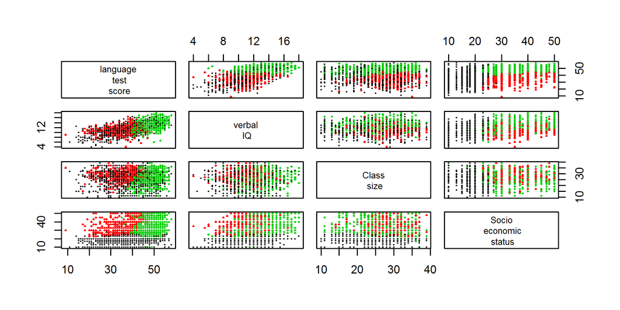

```r
nlcluster = nlschools

# Cluster based on the numeric columns of nlschools, with up to 3 groups
fit = Mclust(nlschools[,c(1,2,4,5) ], G = 1:3)
# the output contains a vector of the cluster labels called fit$classification
nlcluster$cluster = fit$classification
# customize the variable names
labels = c('language\n test\n score', 'verbal\n IQ', 'Class\n size', 'Socio\n economic\n status')

# create the scatterplot matrix. cex.labels = font size
pairs(nlschools[,c(1,2,4,5) ], col=nlcluster$cluster, pch = nlcluster$cluster, cex=.2, cex.labels=.8, labels = labels)
```

Findings:

Class size did not seem to indicate any clearly discernable patterns, which justifies the removal of the variable across the above variable selection processes (both linear and non-linear).

[Note: I attempted to add the COMB variable to discern any other patterns. However, due to the nominal nature of the variable, the distinctions among the three groups were obscured (not as clear) in the resulting plot. The above plot shows the clearest distinctions.]

# Conclusion

In retrospect, the following are my thoughts and conclusions in regards to the guiding questions:

**1. Are there descrepancies in `IQ` or `SES` in the different classes, or when grouping by multi-grade vs non-multi-grade classes?**

Yes, there were discrepancies in IQ and SES among the different classes. Looking at the individual classes according to IQ or SES provided an insigihtful distribution of how the classes differed particularly when 95% confidence intervals differed. However, examining a feature of the classes was much more informative. It was revealed in a plot and in a t test that pupil IQ and SES differed in that smarter and more rich students tended to be in singlegrade classes. This implies that multigrade classes indicate or cater to pupils with a lack of resources or who need more academic aid.

**2. When did students perform better or worse on the language exam? Describe which variables had the most important effects.**

Considering the above, I was not surprised that in predicting language exam scores the backwards and forwards variable selection heuristics chose to keep SES, IQ, and COMB as informative variables. The nonlinear GAM model’s choice in forward selection to add a nonlinear (df = 2) SES variable also indicated the complex interaction SES may have with other variables in the model in predicting language exam scores.

**3. Do you think there are interactions in the effects of the variables on the language exam score? Speculate as to the cause of any such effects that you think should be included.**

While the interaction GAM model indicated that IQ and Class Type was an informative interaction, I was not partcularly convinced since the residual plot for the term showed non-identically distributed residuals–something else may have more of a weight in predicting language exam scores. The co-plots that conditioned based on SES or IQ showed that while IQ predicted language exam scores (e.g., high IQ indicated higher exam score), SES altered the linear relationship–partocularly for the high SES pupils. The model-based clustering graph made the relationship much more concrete by showing the three groups of pupils. The groups demonstrated the moderating effect of SES in that low IQ and high SES individuals were shown as a separate group that tended to obtain better exam scores that low IQ and low SES individuals. The distinction was clearly visualized via the model clustering model. Future analysis may the use of different models to better model the variable contributions to language test scores with more of a focus on the distinctive groups that the model clustering model demonstrated.